# LSTM_demo

## Demonstration of LSTM Networks for Identification of Nonlinear Dynamic Systems

LSTM neural networks are a powerful tool for modelling nonlinear sequence data. They are a form of recurrent neural networks specifically designed to better deal with long term effects. Being a kind of RNN, LSTMs work by making repeated predictions using the same network and weights but by passing the activation values of the network after prediction at $t=i$ as additional inputs for the prediction at $t=i+1$. In a traditional system ID sense this is conceptually similar to an AR model passing previous output values. In an LSTM for example, the "endogenous" input which we pass between steps is the memory state $h_i$. This memory state is of a dimension which can be chosen as a hyper-parameter, with a larger dimension giving more expressive power, similarly to a larger Auto-regressive value. It is noteworthy however, that the way in which this internal state is updated is also learned during training, as such, the LSTM can learn dependencies from arbitrarily long lengths within the data. The LSTM cell uses a series of "Gate functions", these control how the memory state of the model develops over time. The memory state is then passed as output from the LSTM at which point it is typical to stack a dense layer on this for the final output prediction. This allows the hidden state to be of greater dimension than the predicted output. A nice and more thorough description of LSTMs is given in : https://colah.github.io/posts/2015-08-Understanding-LSTMs/.

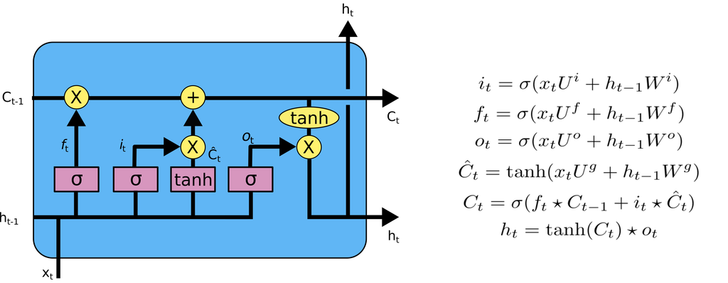

To demonstrate how to use an LSTM network for such a system ID problem, we take a dataset from a series of experiments carried out at Los Alamos national lab. The experiment involves a 3 story shear frame structure excited by ground motion applied by a shaker, nonlinearity is intoduced to the system with a bumper between the 2nd and 3rd storeys. For each experimental setup we have a known input acceleration time history applied to the base and uni-axial accelerations are measured at each floor of the structure.

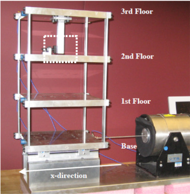

For the given experimental setup, the dataset contains 50 repeated runs with different random time series used for the ground motion. The system ID problem consists of using the 1 dimensional forcing input to predict the 3 dimensional acceleration time series response at each of the floors. As such we use a certain number of the 50 repeats for training and test the performance of the neural network on predicting response for some unseen repeats.

# Import all the modules and functions used

- Tensorflow for modelling (version 2.6.0)
- Matplotlib imported for plotting
- Numpy used for importing and processing data
- glob used for linux type file name searching
- time used for timing simulations

```python
import tensorflow as tf
import tensorflow.keras.backend as K
from tensorflow.keras.models import Sequential
from tensorflow.keras.layers import LSTM, Dense
from tensorflow.keras.callbacks import EarlyStopping, ModelCheckpoint
from tensorflow.keras import optimizers
import matplotlib.pyplot as plt
from math import floor
import numpy as np
from glob import glob
import time
print(tf.version.VERSION)
```

```
2.6.0
```

# Load and Normalise Data

We have seperate files containing base excitations and response accelerations for each of the 50 experiment repeats. We first find a list of file paths for the input and response files. We then load each of these files as numpy arrays into lists in which each list element is one such array. Additionaly, we pad the front of each array with some zeros,

We take the first 25 experiment repeats for training, note we keep the training runs as seperate arrays for now to aid in processing the data to train the LSTM. We then find max and min values in the training datasets and then apply a -1 to 1 normalisation on both the forcing and acceleration datasets. Normalisation can have a very big effect on the efficiency of training with an LSTM.

```python
Forcefiles=glob('**/LANL_state_12_base_accel_M_*.csv',recursive=True)
Forcefiles.sort()
Encodedfiles = filelist = glob('**/LANL_state_12_original_accelerations_M_*.csv',recursive=True)
Encodedfiles.sort()

FF = []
for file in Forcefiles:
    ff = np.loadtxt(open(file,"rb"), delimiter=",").reshape((-1,1))
    ff = np.concatenate((np.zeros((120,1)),ff),axis=0)
    FF.append(ff)

Ftrain = FF[:25] # First 5 taken for training

nT = FF[0].shape[0] # Number of sample points in each experimental run

Fn = np.concatenate((Ftrain),axis=0) #Fn create only to find normalsing max and min values
Fmax = Fn.max(axis=0,keepdims=True)
Fmin = Fn.min(axis=0,keepdims=False)


YY = []
for file in Encodedfiles:
    yy = np.loadtxt(open(file,"rb"), delimiter=",")
    yy = np.concatenate((np.zeros((120,3)),yy),axis=0)
    YY.append(yy)

Ytrain = YY[:25]

Yn = np.concatenate((Ytrain),axis=0)
Ymax = Yn.max(axis=0,keepdims=True)
Ymin = Yn.min(axis=0,keepdims=False)

FFN = Ftrain
for i in range(len(FFN)):
  FFN[i] = 2*(FFN[i]-Fmin)/(Fmax-Fmin)-1

YYN = Ytrain
for i in range(len(YYN)):
  YYN[i] = 2*(YYN[i]-Ymin)/(Ymax-Ymin)-1
```

# Create Training Dataset

Creating a training dataset is quite involved for LSTM networks. Recurrent neural networks are trained using the back-propagation through time algorithm (BPTT), whilst we can theoretically propagate errors through infinite time steps, in practice this doesn't work well even for LSTM networks. As such, we have to use truncated BPTT which for each training example only makes forward and backward runs for a limited number of time steps. As such, we must create a dataset of training input samples in which each sample is a matrix of shape $(look\_back, n\_features)$ in which look_back is the length of each seuquence used in the TBPTT training algorithm, this also is the limit of the longest relationship which can be learned by the network. The second dimension n_features corresponds to the dimension of the input vector at each time point, in this case, 4, one value of the forcing input at this time point and 3 acceleration values of the output from the previous time step. The full input dataset for the training is as such a 3D tensor of shape $(n\_samples, look\_back, n\_features)$. The output data on the other hand simply takes the conventional shape $(n\_samples, f\_features)$ with feature dimension being 3 of the 3 predicted accelerations.

Also it is noteworthy that in this case we explicitly add the acceleration response at time $t=i$ as an exogenous input for the prediction at $t=i+1$, in other words we include an autoregression of order 1. This is not the usual way to setup an RNN, normally the internal state is the only thing propagated between time steps, it was found however, that explictily adding the previous output value leads to more favourable training.

```python
DDN = []
for i in range(len(YYN)):
  DDN.append(np.concatenate((FFN[i],YYN[i]),axis=1))
look_back = 120

def create_dataset(dataset, look_back=look_back):
    X, Y = [], []
    for i in range(len(dataset)-look_back-1):
        a = dataset[i:(i+look_back), :]
        X.append(a)
        Y.append(dataset[i + look_back, 1:])
    return np.array(X), np.array(Y)

XY=[]
for i in range(len(DDN)):
    XY.append(create_dataset(DDN[i]))

xtrain, ytrain = zip(*XY)
xtrain = list(xtrain)
ytrain = list(ytrain)
x_t = np.concatenate(xtrain,axis=0)
y_t = np.concatenate(ytrain,axis=0)
x_train = x_t[:floor(0.8*x_t.shape[0]),:]
y_train = y_t[:floor(0.8*x_t.shape[0]),:]
x_val = x_t[floor(0.8*x_t.shape[0]):,:]
y_val = y_t[floor(0.8*x_t.shape[0]):,:]
```

# Setup LSTM for Training

Firstly we define some training settings for the network. The callbacks: early stopping and checkpoint combined, are used to stop the training early once the validation loss is no longer decreasing and to save the weights of the training epoch which achieved the lowest validation error. We also defined an adam optimiser which uses a learning rate which decreases during training.

The LSTM model is then defined, we define a model which consists of a single LSTM layer with a 15 dimensional hidden state, stacked on this is a fully-connected layer of dimension 3. Note the hidden layer dimension is a hyperparameter to be chosen where as the dense layer dimension is dictated by the problem, in this case 3 dimensions for the 3 predicted accelerations. The model is fit for 100 epochs with possible early stopping and the best weighs reloaded after training.

```python
earlystopping = EarlyStopping(monitor='val_loss', min_delta=1e-9, patience = 20)
checkpoint = ModelCheckpoint('.lstm_wts.hdf5', verbose=1, monitor='val_loss',save_best_only=True, mode='auto')
callbacksList = [earlystopping, checkpoint]
lr = tf.keras.optimizers.schedules.ExponentialDecay(
    initial_learning_rate=5e-3,
    decay_steps=1000,
    decay_rate=0.96)
Adopt= optimizers.Adam(learning_rate=lr, beta_1=0.9, beta_2=0.999, clipnorm=1)

lstm = Sequential()
lstm.add(LSTM(15,stateful=False, input_shape=(x_train.shape[1],x_train.shape[2])))
lstm.add(Dense(3,activation='linear'))
lstm.compile(optimizer=Adopt, loss='mean_squared_error')
lstm.load_weights(filepath='.lstm_wts.hdf5')
lstm.fit(x_train,y_train, epochs=100, batch_size=1024,verbose=1,validation_data=(x_val,y_val), callbacks=callbacksList)
lstm.load_weights(filepath = '.lstm_wts.hdf5')
```

```
       Epoch 00001: val_loss improved from inf to 0.00005, saving model to .lstm_wts.hdf5

       Epoch 00002: val_loss improved from 0.00005 to 0.00005, saving model to .lstm_wts.hdf5

       Epoch 00003: val_loss improved from 0.00005 to 0.00005, saving model to .lstm_wts.hdf5

       Epoch 00004: val_loss did not improve from 0.00005

       Epoch 00005: val_loss did not improve from 0.00005

       Epoch 00006: val_loss did not improve from 0.00005

       Epoch 00007: val_loss did not improve from 0.00005

       Epoch 00008: val_loss improved from 0.00005 to 0.00005, saving model to .lstm_wts.hdf5

       Epoch 00009: val_loss did not improve from 0.00005

       Epoch 00010: val_loss did not improve from 0.00005

       Epoch 00011: val_loss did not improve from 0.00005

       Epoch 00012: val_loss did not improve from 0.00005

       Epoch 00013: val_loss improved from 0.00005 to 0.00005, saving model to .lstm_wts.hdf5

       Epoch 00014: val_loss did not improve from 0.00005

       Epoch 00015: val_loss did not improve from 0.00005

       Epoch 00016: val_loss did not improve from 0.00005

       Epoch 00017: val_loss did not improve from 0.00005

       Epoch 00018: val_loss did not improve from 0.00005

       Epoch 00019: val_loss did not improve from 0.00005

       Epoch 00020: val_loss improved from 0.00005 to 0.00005, saving model to .lstm_wts.hdf5

```

[output cut: 62 more lines]

```
       Epoch 00052: val_loss did not improve from 0.00004

       Epoch 00053: val_loss did not improve from 0.00004

       Epoch 00054: val_loss did not improve from 0.00004

       Epoch 00055: val_loss did not improve from 0.00004

       Epoch 00056: val_loss did not improve from 0.00004

       Epoch 00057: val_loss did not improve from 0.00004

       Epoch 00058: val_loss did not improve from 0.00004

       Epoch 00059: val_loss did not improve from 0.00004
```

# Create a Prediction Model

```python
lstm.load_weights('.lstm_wts.hdf5')
lstmPred = Sequential()
lstmPred.add(LSTM(15,stateful=True,batch_input_shape=(1,1,x_train.shape[2]),unroll=True))
lstmPred.add(Dense(3,activation='linear'))
lstmPred.set_weights(lstm.get_weights())
#lstmPred.save_weights('prettygood.hdf5')
lstmPred.load_weights('prettygood.hdf5')
```

We then take one of the datasets not used for training and apply the correct normalisation. We can then create our prediction loop. For each prediciton we give as input the concatenation of the forcing at time i and the predicted response from the previous step. Since we have here used a stateful LSTM network, this state value is propagated by itself. However, as it is a stateful network we must be mindful to reset this state to initialisation before beginning the predictions.

```python
Ftest = FF[-1]
Ytest = YY[-1]
FtestN = 2*(Ftest-Fmin)/(Fmax-Fmin)-1
YtestN = 2*(Ytest-Ymin)/(Ymax-Ymin)-1
datasetTest=np.concatenate((FtestN,YtestN),axis=1)
dataTest = np.reshape(datasetTest,(-1,1,datasetTest.shape[1]))
lstmPred.reset_states()
@tf.function
def makePred(lstmPred,Ti):
    return lstmPred(Ti)
zz1=[]
x0 = dataTest[0:1,:,:]
print(dataTest.shape)
print(type(dataTest))
t = time.time()
for i in range(0,8000):
        zzz = makePred(lstmPred,x0)
        zz1.append(zzz)
        zzz = np.reshape(zzz,(1,1,3))
        x0 = np.concatenate((dataTest[i+1:i+2,:,0:1],zzz),axis=2)
print(time.time()-t)
z = np.squeeze(np.concatenate(zz1,axis=0))
```

```
(8312, 1, 4)
<class 'numpy.ndarray'>
10.957023620605469
```